# Predictive Models for NFL Betting Strategies

# By Smruthi Iyengar, Geoffrey Myers, and Eric Nakamoto

## Table of Contents:

1. Executive Summary
2. Data Cleaning and Transformation
   - Inital Variable & Irrelevant Observation Removal
   - Dealing With Missing Values
   - Transformation
   - Post Transformation Variable Removal
   - Scaling
3. Exploratory Phase
   - Summary Statistics of The Target Variables
   - Summmary Statistics of the Numerical Predictors
   - Summary Statistics of the Categorical Predictors
   - Clustering
     - Clustering Summary
4. Supervised Learning
   - k-Nearest Neighbors
     - Manhattan kNN evaluation
     - Euclidean kNN evaluation
     - Chebyshev kNN evaluation
     - kNN Evaluation Summary
   - Decision Trees
     - Predicting OverBeat
     - Predicting SpreadWin
     - Decision Tree Summary
   - Regression
     - Model Building
     - Evaluation
     - Regression Summary
5. Conclusion
   - Opportunities for Enhancement

# Executive Summary

Online sports betting is becoming legalized and more ubiquitous in many states. Unlike many other forms of betting (ex. poker, blackjack, roulette, craps, etc.), sports betting isn’t predicated on pre-defined and well known probabilities/odds. The inspiration for this project is to assess if through the use of machine learning there are any interesting findings that could lead to successful betting strategies for NFL game betting. We will attempt to accomplish this by leveraging the "NFL Scores and Betting Data" data set on Kaggle found here, https://www.kaggle.com/tobycrabtree/nfl-scores-and-betting-data. To give this a real world goal and metric to compare against we'll also perform a comparison on expected returns our models could have versus major stock indices like the S&P 500, Dow Jones, and NASDAQ to give a sense of opportunity cost.

To try to answer these questions, we first used clustering in order to see if there were any interesting groups in the data. As it turned out, most of the data clustered in one big blob, leading to poor clustering results. This poor result somewhat indicated that we would see less than stellar results from our next task, which was applying supervised learning techniques. The supervised learning methods we attempted were k-nearest neighbors, decision trees, and logistic regression. From all three of those methods, we saw rather poor performance, which the classifiers being roughly the same as random chance. We did see some elevated performance from predicting specific cases, such as looking at only the predictions for bets of the over-under being over. Though, the overall poor performance does not instill a lot of confidence in using these models widely.

While in the scope of our project, we found poor results, there are further avenues to explore that could lead to more fruitful results. One of the major additions would be to add more variables, specific variables relating to team performance, to the dataset. We saw in our analysis that the four variables that related to team performance were in important to many models. Other learning techniques could be tried, such as SVM or even ensemble techniques that leverage multiple models.

## Breakdown of Contributions

- Smruthi Iyengar
  - Exploratory Phase except Clustering section
  - Decision Trees
- Eric Nakamoto
  - Clustering
  - k-Nearest Neighbors
- Geoffrey Myers
  - Data Cleaning and Transformation
  - Regression

The executive summary and conclusion were written collaboratively. Everyone contributed to the editing of the overall document.

# Data Cleaning and Transformation

The first major task of this project was to preprocess the data in order to get it into a more useable state. The original dataset included 12627 observations and 22 variables. The main reason for preprocessing is that there is a fair amount of missing data and irrelevant features. The second major task was variable transformation. A major part of that task to add the labels to the data. The first label is if the spread was beat by the favored team, meaning that the favored team had a margin of victory greater than the spread, which the spread in this set is represented by spread favorite. Another major part of the transformation task is to scale the numerical features, as there are a wide range of values in this data set. If they were left unscaled, then the larger value variables could dominate the models. Finally, the categorical variables will be converted into dummy variables. The first part of this task, the removal of some irrelevant features and observations, is detailed below.

## Imports for Cleaning And Transformation

```python
import pandas as pd
import numpy as np
from sklearn import preprocessing
```

## Inital Variable & Irrelevant Observation Removal

One of the largest chunks of missing data comes from the fact that the sports betting site that was used to generate the betting features (team favorite id, spread favorite, and over under line) only had data dating back to the 1978 season. So, all seasons prior to that need to be removed due to that lack of sports betting information. Another section of data that needs to be processed are games in which there are no favorite. These rows need to be removed as they make it difficult to generate the label for the spread as betting on the spread just becomes picking the winning team. Most of the irrelevant features relate to the season schedule (schedule data and schedule week) and are not useful features for machine learning. Below goes through the individual steps to accomplish this part of the task.

First, we'll remove schedule_date and schedule_week. They were removed due as they do not make sense to use a predictors.

```python
data = pd.read_csv("/content/merged.csv", header=0)
# Removing some insignificant columns, keeping schedule_season for easier data cleaning later
dataReduced = data.drop(['Unnamed: 0', 'schedule_date', 'schedule_week'], axis = 1)
```

Next, we'll remove data from seasons before 1979 as they do not include betting data that is vital to our analysis.

```python
# removing data prior to the 1978 due to the lack of betting data
dataReduced = dataReduced.loc[dataReduced['schedule_season'] > 1978]
```

We'll also remove the rows were there is no favorite, as it changes a bet on the spread to just picking a winner, which makes it impossible to add a label for if betting on the spread was a winning spread. Due to its difficulty in labeling and it being a small portion of the data, we felt it was best to just remove those rows

```python
dataReduced.loc[dataReduced['team_favorite_id'] == 'PICK'].shape[0]
```

```
139
```

```python
dataReduced = dataReduced.loc[dataReduced['team_favorite_id'] != 'PICK']
dataReduced.shape
```

```
(10173, 19)
```

## Dealing With Missing Values

This next part of cleaning and process will be on handling other missing values in the data. Most of the other missing values relate to the weather data. There are also some missing values for the over under line. To deal with the weather data, specifically the temperature and wind speed, the rows with the missing data will be removed. While it could be possible to source all of the missing weather data, it would be rather difficult and time consuming due each missing value being a different date and location. We also chose to remove the observations with the missing over-under line as there was only 61 observations with it missing. The data set is large enough that removing the values still leaves us with over 9000 observations. Weather humidity also had quite a few missing values. We chose to replace the missing values with zero as there was over 3000 missing values, which was too large of a portion of data. We also chose to replace it with zero as over 2000 of the observations with missing values were games that were played in domes, meaning there was likely zero humidity. Finally, the last variable with missing values was weather detail, though they were not truly missing as an NA in that row just indicated no special weather detail occurred on the day. Converting that variable into dummy variables got rid of the last of the missing values. Below is a more detailed look at how the missing values were delt with.

We'll now check to see if there is missing data in our dataset.

```python
dataReduced.isnull().sum()
```

```
schedule_season           0
schedule_playoff          0
team_home                 0
score_home                0
score_away                0
team_favorite_id          0
spread_favorite           0
over_under_line          61
stadium                   0
stadium_neutral           0
weather_temperature     681
weather_wind_mph        698
weather_humidity       4117
weather_detail         7661
homePointsFor             0
homePointsAgainst         0
team_away                 0
awayPointsFor             0
awayPointsAgainst         0
dtype: int64
```

We'll first deal with the misssing over_under_line rows. It seems that we 61 rows that have missing over_under_line from the early part of our dataset as its only missing up until 1985.

```python
dataReduced.loc[dataReduced['over_under_line'].isna()]
```

|  | schedule_season | schedule_playoff | team_home | score_home | score_away | team_favorite_id | spread_favorite | over_under_line | stadium | stadium_neutral | weather_temperature | weather_wind_mph | weather_humidity | weather_detail | homePointsFor | homePointsAgainst | team_away | awayPointsFor | awayPointsAgainst |
| --- | --- | --- | --- | --- | --- | --- | --- | --- | --- | --- | --- | --- | --- | --- | --- | --- | --- | --- | --- |
| 2523 | 1979 | True | Houston Oilers | 13 | 7 | TEN | -7.0 | NaN | Houston Astrodome | False | 72.0 | 0.0 | NaN | DOME | 22.6250 | 20.6875 | Denver Broncos | 18.0625 | 16.3750 |
| 2524 | 1979 | True | Philadelphia Eagles | 27 | 17 | PHI | -6.5 | NaN | Veterans Stadium | False | NaN | NaN | NaN | NaN | 21.1875 | 17.6250 | Chicago Bears | 19.1250 | 15.5625 |
| 2525 | 1979 | True | San Diego Chargers | 14 | 17 | LAC | -8.0 | NaN | Qualcomm Stadium | False | NaN | NaN | NaN | NaN | 25.6875 | 15.3750 | Houston Oilers | 22.6250 | 20.6875 |
| 2526 | 1979 | True | Tampa Bay Buccaneers | 24 | 17 | PHI | -4.5 | NaN | Houlihan's Stadium | False | NaN | NaN | NaN | NaN | 17.0625 | 14.8125 | Philadelphia Eagles | 21.1875 | 17.6250 |
| 2527 | 1979 | True | Dallas Cowboys | 19 | 21 | DAL | -8.5 | NaN | Texas Stadium | False | NaN | NaN | NaN | NaN | 23.1875 | 19.5625 | Los Angeles Rams | 20.1875 | 19.3125 |
| ... | ... | ... | ... | ... | ... | ... | ... | ... | ... | ... | ... | ... | ... | ... | ... | ... | ... | ... | ... |
| 3742 | 1985 | True | Miami Dolphins | 24 | 21 | MIA | -10.5 | NaN | Orange Bowl | False | NaN | NaN | NaN | NaN | 26.7500 | 20.0000 | Cleveland Browns | 17.9375 | 18.3750 |
| 3743 | 1985 | True | Chicago Bears | 21 | 0 | CHI | -9.0 | NaN | Soldier Field | False | NaN | NaN | NaN | NaN | 28.5000 | 12.3750 | New York Giants | 24.9375 | 17.6875 |
| 3744 | 1985 | True | Los Angeles Raiders | 20 | 27 | LVR | -5.5 | NaN | Los Angeles Memorial Coliseum | False | NaN | NaN | NaN | NaN | 22.1250 | 19.2500 | New England Patriots | 22.6250 | 18.1250 |
| 3745 | 1985 | True | Chicago Bears | 24 | 0 | CHI | -10.5 | NaN | Soldier Field | False | NaN | NaN | NaN | NaN | 28.5000 | 12.3750 | Los Angeles Rams | 21.2500 | 17.3125 |
| 3746 | 1985 | True | Miami Dolphins | 14 | 31 | MIA | -5.5 | NaN | Orange Bowl | False | NaN | NaN | NaN | NaN | 26.7500 | 20.0000 | New England Patriots | 22.6250 | 18.1250 |

61 rows × 19 columns

We chose to remove the rows with the missing over-under line, as it did not make up a significant portion of our data. We also chose to remove the rows that had missing data for the temperature and wind as it would be rather difficult to replace those values and it was also not a significant portion of our data.

```python
dataReduced.loc[dataReduced['over_under_line'].isna()]
```

|  | schedule_season | schedule_playoff | team_home | score_home | score_away | team_favorite_id | spread_favorite | over_under_line | stadium | stadium_neutral | weather_temperature | weather_wind_mph | weather_humidity | weather_detail | homePointsFor | homePointsAgainst | team_away | awayPointsFor | awayPointsAgainst |
| --- | --- | --- | --- | --- | --- | --- | --- | --- | --- | --- | --- | --- | --- | --- | --- | --- | --- | --- | --- |
| 2523 | 1979 | True | Houston Oilers | 13 | 7 | TEN | -7.0 | NaN | Houston Astrodome | False | 72.0 | 0.0 | NaN | DOME | 22.6250 | 20.6875 | Denver Broncos | 18.0625 | 16.3750 |
| 2524 | 1979 | True | Philadelphia Eagles | 27 | 17 | PHI | -6.5 | NaN | Veterans Stadium | False | NaN | NaN | NaN | NaN | 21.1875 | 17.6250 | Chicago Bears | 19.1250 | 15.5625 |
| 2525 | 1979 | True | San Diego Chargers | 14 | 17 | LAC | -8.0 | NaN | Qualcomm Stadium | False | NaN | NaN | NaN | NaN | 25.6875 | 15.3750 | Houston Oilers | 22.6250 | 20.6875 |
| 2526 | 1979 | True | Tampa Bay Buccaneers | 24 | 17 | PHI | -4.5 | NaN | Houlihan's Stadium | False | NaN | NaN | NaN | NaN | 17.0625 | 14.8125 | Philadelphia Eagles | 21.1875 | 17.6250 |
| 2527 | 1979 | True | Dallas Cowboys | 19 | 21 | DAL | -8.5 | NaN | Texas Stadium | False | NaN | NaN | NaN | NaN | 23.1875 | 19.5625 | Los Angeles Rams | 20.1875 | 19.3125 |
| ... | ... | ... | ... | ... | ... | ... | ... | ... | ... | ... | ... | ... | ... | ... | ... | ... | ... | ... | ... |
| 3742 | 1985 | True | Miami Dolphins | 24 | 21 | MIA | -10.5 | NaN | Orange Bowl | False | NaN | NaN | NaN | NaN | 26.7500 | 20.0000 | Cleveland Browns | 17.9375 | 18.3750 |
| 3743 | 1985 | True | Chicago Bears | 21 | 0 | CHI | -9.0 | NaN | Soldier Field | False | NaN | NaN | NaN | NaN | 28.5000 | 12.3750 | New York Giants | 24.9375 | 17.6875 |
| 3744 | 1985 | True | Los Angeles Raiders | 20 | 27 | LVR | -5.5 | NaN | Los Angeles Memorial Coliseum | False | NaN | NaN | NaN | NaN | 22.1250 | 19.2500 | New England Patriots | 22.6250 | 18.1250 |
| 3745 | 1985 | True | Chicago Bears | 24 | 0 | CHI | -10.5 | NaN | Soldier Field | False | NaN | NaN | NaN | NaN | 28.5000 | 12.3750 | Los Angeles Rams | 21.2500 | 17.3125 |
| 3746 | 1985 | True | Miami Dolphins | 14 | 31 | MIA | -5.5 | NaN | Orange Bowl | False | NaN | NaN | NaN | NaN | 26.7500 | 20.0000 | New England Patriots | 22.6250 | 18.1250 |

61 rows × 19 columns

```python
dataReduced = dataReduced.loc[dataReduced['over_under_line'].notna()]
dataReduced = dataReduced.loc[dataReduced['weather_temperature'].notna()]
dataReduced = dataReduced.loc[dataReduced['weather_wind_mph'].notna()]
```

```python
dataReduced.shape
```

```
(9471, 19)
```

Next, we'll look at where the values of humidity are missing to determine how to handle it. The missing data seems to come from both domes, which would not have any humidity, or the values are just missing. The values missing could indicate that either there was no data or that there was not humidity on the day.

```python
dataReduced.loc[dataReduced['weather_humidity'].isna()]
```

|  | schedule_season | schedule_playoff | team_home | score_home | score_away | team_favorite_id | spread_favorite | over_under_line | stadium | stadium_neutral | weather_temperature | weather_wind_mph | weather_humidity | weather_detail | homePointsFor | homePointsAgainst | team_away | awayPointsFor | awayPointsAgainst |
| --- | --- | --- | --- | --- | --- | --- | --- | --- | --- | --- | --- | --- | --- | --- | --- | --- | --- | --- | --- |
| 2322 | 1979 | False | New Orleans Saints | 34 | 40 | NO | -5.0 | 32.0 | Louisiana Superdome | False | 72.0 | 0.0 | NaN | DOME | 23.1250 | 22.5000 | Atlanta Falcons | 18.7500 | 24.2500 |
| 2325 | 1979 | False | Seattle Seahawks | 16 | 33 | SEA | -2.0 | 42.5 | Seattle Kingdome | False | 72.0 | 0.0 | NaN | DOME | 23.6250 | 23.2500 | San Diego Chargers | 25.6875 | 15.3750 |
| 2346 | 1979 | False | Houston Oilers | 20 | 6 | TEN | -5.0 | 37.0 | Houston Astrodome | False | 72.0 | 0.0 | NaN | DOME | 22.6250 | 20.6875 | Kansas City Chiefs | 14.8750 | 16.3750 |
| 2349 | 1979 | False | New Orleans Saints | 14 | 26 | NO | -3.0 | 42.0 | Louisiana Superdome | False | 72.0 | 0.0 | NaN | DOME | 23.1250 | 22.5000 | Philadelphia Eagles | 21.1875 | 17.6250 |
| 2352 | 1979 | False | Seattle Seahawks | 27 | 10 | SEA | -3.0 | 44.0 | Seattle Kingdome | False | 72.0 | 0.0 | NaN | DOME | 23.6250 | 23.2500 | Oakland Raiders | 22.8125 | 21.0625 |
| ... | ... | ... | ... | ... | ... | ... | ... | ... | ... | ... | ... | ... | ... | ... | ... | ... | ... | ... | ... |
| 12604 | 2020 | False | Detroit Lions | 35 | 37 | MIN | -3.0 | 53.5 | Ford Field | False | 72.0 | 0.0 | NaN | DOME | 23.5625 | 32.4375 | Minnesota Vikings | 26.8750 | 29.6875 |
| 12605 | 2020 | False | Houston Texans | 38 | 41 | TEN | -7.0 | 55.5 | NRG Stadium | False | 72.0 | 0.0 | NaN | DOME | 24.0000 | 29.0000 | Tennessee Titans | 30.6875 | 27.4375 |
| 12606 | 2020 | False | Indianapolis Colts | 28 | 14 | IND | -15.5 | 48.0 | Lucas Oil Stadium | False | 72.0 | 0.0 | NaN | DOME | 28.1875 | 22.6250 | Jacksonville Jaguars | 19.1250 | 30.7500 |
| 12617 | 2020 | True | New Orleans Saints | 21 | 9 | NO | -11.0 | 48.0 | Mercedes-Benz Superdome | False | 72.0 | 0.0 | NaN | DOME | 30.1250 | 21.0625 | Chicago Bears | 23.2500 | 23.1250 |
| 12623 | 2020 | True | New Orleans Saints | 20 | 30 | NO | -2.5 | 53.0 | Mercedes-Benz Superdome | False | 72.0 | 0.0 | NaN | DOME | 30.1250 | 21.0625 | Tampa Bay Buccaneers | 30.7500 | 22.1875 |

3415 rows × 19 columns

```python
print("Number of weather_humidity NAs: {}".format(dataReduced['weather_humidity'].isna().sum()))
print("Number of Domes : {}".format(dataReduced.loc[dataReduced['weather_detail'] == 'DOME'].shape[0]))
print("Number of weather_humidity NAs for Domes : {}".format(dataReduced.loc[(dataReduced['weather_detail'] == 'DOME') & (dataReduced['weather_humidity'].isna())].shape[0]))
```

```
Number of weather_humidity NAs: 3415
Number of Domes : 2278
Number of weather_humidity NAs for Domes : 2278
```

Since a signifant portion of the NAs in weather humidity result from the stadium being domed, we will just set the humidity to zero for the missing values.

```python
dataReduced.loc[dataReduced['weather_humidity'].isna(), 'weather_humidity'] = 0
```

We now only have NAs in the weather detail column, which will be resolved when that variable is trasformed into dummy variables. NAs in this variable just represent that there was no special weather condition for that game.

```python
dataReduced.isna().sum()
```

```
schedule_season           0
schedule_playoff          0
team_home                 0
score_home                0
score_away                0
team_favorite_id          0
spread_favorite           0
over_under_line           0
stadium                   0
stadium_neutral           0
weather_temperature       0
weather_wind_mph          0
weather_humidity          0
weather_detail         6964
homePointsFor             0
homePointsAgainst         0
team_away                 0
awayPointsFor             0
awayPointsAgainst         0
dtype: int64
```

To finish off this portion of dealing with missing values, we will transform the weather detail variable into a set of dummy variables.

```python
dummies = pd.get_dummies(dataReduced['weather_detail'])
dataReduced = pd.concat([dataReduced, dummies], axis=1)
dataReduced.head()
```

|  | schedule_season | schedule_playoff | team_home | score_home | score_away | team_favorite_id | spread_favorite | over_under_line | stadium | stadium_neutral | weather_temperature | weather_wind_mph | weather_humidity | weather_detail | homePointsFor | homePointsAgainst | team_away | awayPointsFor | awayPointsAgainst | DOME | DOME (Open Roof) | Fog | Rain | Rain \| Fog | Snow | Snow \| Fog | Snow \| Freezing Rain |
| --- | --- | --- | --- | --- | --- | --- | --- | --- | --- | --- | --- | --- | --- | --- | --- | --- | --- | --- | --- | --- | --- | --- | --- | --- | --- | --- | --- |
| 2315 | 1979 | False | Tampa Bay Buccaneers | 31 | 16 | TB | -3.0 | 30.0 | Houlihan's Stadium | False | 79.0 | 9.0 | 87 | NaN | 17.0625 | 14.8125 | Detroit Lions | 13.6875 | 22.8125 | 0 | 0 | 0 | 0 | 0 | 0 | 0 | 0 |
| 2316 | 1979 | False | Buffalo Bills | 7 | 9 | MIA | -5.0 | 39.0 | Ralph Wilson Stadium | False | 74.0 | 15.0 | 74 | NaN | 16.7500 | 17.4375 | Miami Dolphins | 21.3125 | 16.0625 | 0 | 0 | 0 | 0 | 0 | 0 | 0 | 0 |
| 2317 | 1979 | False | Chicago Bears | 6 | 3 | CHI | -3.0 | 31.0 | Soldier Field | False | 78.0 | 11.0 | 68 | NaN | 19.1250 | 15.5625 | Green Bay Packers | 15.3750 | 19.7500 | 0 | 0 | 0 | 0 | 0 | 0 | 0 | 0 |
| 2318 | 1979 | False | Denver Broncos | 10 | 0 | DEN | -3.0 | 31.5 | Mile High Stadium | False | 69.0 | 6.0 | 38 | NaN | 18.0625 | 16.3750 | Cincinnati Bengals | 21.0625 | 26.3125 | 0 | 0 | 0 | 0 | 0 | 0 | 0 | 0 |
| 2319 | 1979 | False | Kansas City Chiefs | 14 | 0 | KC | -1.0 | 37.0 | Arrowhead Stadium | False | 76.0 | 8.0 | 71 | NaN | 14.8750 | 16.3750 | Baltimore Colts | 16.9375 | 21.9375 | 0 | 0 | 0 | 0 | 0 | 0 | 0 | 0 |

We will then remove the weather detail variable, as it is no longer necessary due to the dummy variables.

```python
dataReduced = dataReduced.drop(['weather_detail'], axis = 1)
```

Now we no longer have any missing values in our dataset.

```python
dataReduced.isna().sum()
```

```
schedule_season         0
schedule_playoff        0
team_home               0
score_home              0
score_away              0
team_favorite_id        0
spread_favorite         0
over_under_line         0
stadium                 0
stadium_neutral         0
weather_temperature     0
weather_wind_mph        0
weather_humidity        0
homePointsFor           0
homePointsAgainst       0
team_away               0
awayPointsFor           0
awayPointsAgainst       0
DOME                    0
DOME (Open Roof)        0
Fog                     0
Rain                    0
Rain | Fog              0
Snow                    0
Snow | Fog              0
Snow | Freezing Rain    0
dtype: int64
```

## Transformations

First, we'll start with generating our first label for beating the over-under. The first step to calculate the total points in each game.

```python
dataReduced['pointTotal'] = np.sum(dataReduced.iloc[:, 3:5],axis=1).tolist()
```

Now we'll generate the label which we will name overBeat. 1 will be for when the total points in the game is greater than the over-under line. 0 is for when the total points in the game is less than the over-under line. -1 represents a push or when the total number of points is exactly the over-under line.

```python
dataReduced.loc[dataReduced['pointTotal'] > dataReduced['over_under_line'], 'overBeat'] = 1
dataReduced.loc[dataReduced['pointTotal'] < dataReduced['over_under_line'], 'overBeat'] = 0
dataReduced.loc[dataReduced['pointTotal'] == dataReduced['over_under_line'], 'overBeat'] = -1
```

```python
dataReduced[dataReduced['overBeat'] == -1].shape
```

```
(177, 28)
```

Next, we'll work on generating the second label, which is for if the spread was beat. We'll start by reading in nfl teams file so we can change the home and away to team ids as they are currently just the full name, while the favored team is in ID form.

```python
teams = pd.read_csv("/content/nfl_teams.csv")
teams.head()
```

|  | team_name | team_name_short | team_id | team_id_pfr | team_conference | team_division | team_conference_pre2002 | team_division_pre2002 |
| --- | --- | --- | --- | --- | --- | --- | --- | --- |
| 0 | Arizona Cardinals | Cardinals | ARI | CRD | NFC | NFC West | NFC | NFC West |
| 1 | Phoenix Cardinals | Cardinals | ARI | CRD | NFC | NaN | NFC | NFC East |
| 2 | St. Louis Cardinals | Cardinals | ARI | ARI | NFC | NaN | NFC | NFC East |
| 3 | Atlanta Falcons | Falcons | ATL | ATL | NFC | NFC South | NFC | NFC West |
| 4 | Baltimore Ravens | Ravens | BAL | RAV | AFC | AFC North | AFC | AFC Central |

Now we'll change the team home value to be an id instead of a team name.

```python
temp = pd.merge(dataReduced, teams, left_on = 'team_home', right_on="team_name")
# Getting just team id
temp = temp.iloc[:,np.r_[0:28, 30]]
temp['team_home'] = temp['team_id']
```

And then we'll adjust the team away value to be an id instead of team name and reset our dataset to remove the extra variables that came in with the nfl teams dataset.

```python
temp = pd.merge(temp, teams, left_on = 'team_away', right_on="team_name")
temp = temp.iloc[:,np.r_[0:28, 31]]
temp['team_away'] = temp['team_id_y']
dataReduced = temp.iloc[:,0:28]
```

Now we'll generate the label and name it spreadWin. To do that we'll first tackle if the home team is the favored team. If the difference between the home score and away score is greater than the spread, then that represents a covering of the spread, which will be represented by 1. 0 will represent if the home score minus the away score is not greater than the spread and -1 will represent when the home score minus the away score is exactly the spread. That -1 case indicates a push where no one wins.

```python
dataReduced.loc[(dataReduced['team_home'] == dataReduced['team_favorite_id']) &
                (dataReduced['score_home'] - dataReduced['score_away'] > abs(dataReduced['spread_favorite'])), 'spreadWin'] = 1
dataReduced.loc[(dataReduced['team_home'] == dataReduced['team_favorite_id']) &
                (dataReduced['score_home'] - dataReduced['score_away'] < abs(dataReduced['spread_favorite'])), 'spreadWin'] = 0
dataReduced.loc[(dataReduced['team_home'] == dataReduced['team_favorite_id']) &
                (dataReduced['score_home'] - dataReduced['score_away'] == abs(dataReduced['spread_favorite'])), 'spreadWin'] = -1
```

We'll then do the same as above for if the away team is favored.

```python
dataReduced.loc[(dataReduced['team_away'] == dataReduced['team_favorite_id']) &
                (dataReduced['score_away'] - dataReduced['score_home'] > abs(dataReduced['spread_favorite'])), 'spreadWin'] = 1
dataReduced.loc[(dataReduced['team_away'] == dataReduced['team_favorite_id']) &
                (dataReduced['score_away'] - dataReduced['score_home'] < abs(dataReduced['spread_favorite'])), 'spreadWin'] = 0
dataReduced.loc[(dataReduced['team_away'] == dataReduced['team_favorite_id']) &
                (dataReduced['score_away'] - dataReduced['score_home'] == abs(dataReduced['spread_favorite'])), 'spreadWin'] = -1
```

There are 269 pushes for the spread.

```python
dataReduced[dataReduced['spreadWin'] == -1].shape
```

```
(269, 29)
```

We chose to drop the pushes for both the spread and over-under as our analysis is focusing on trying to finding insights into winning bets and that there are not a significant number that we felt it was necessary to keep them in.

```python
dataReduced = dataReduced.loc[dataReduced['spreadWin'] != -1]
dataReduced = dataReduced.loc[dataReduced['overBeat'] != -1]
dataReduced.shape
```

```
(9027, 29)
```

Next, we'll adjust the spread favorite to positive, as it is only negative due to nature of the spread and as a predictor it makes more sense for it to be positive.

```python
dataReduced['spread_favorite'] = abs(dataReduced['spread_favorite'])
```

We'll save a copy of our dataframe so that we can create an experimental dataframe that contains dummy variables for all of the categorical variables

```python
dataReducedAlt = dataReduced.copy()
```

## Post Transformation Variable Removal

Here we are removing a lot of variables that are not important. Schedule season was removed as it does not make sense as a predictor and was only helpful during variable transformation to make sense of missing values. Stadium was removed at it would have to be transfomred to dummies and it would have increased the dimensionality too much. Team home,team away, and team favorite id were also removed due the previously discussed dimensionality issues. Point total, score home, and score away were removed that they were only useful in generating the labels for the data.

```python
dataReduced = dataReduced.drop(['schedule_season', 'stadium', 'team_home', 'team_favorite_id', 'team_away', 'pointTotal', 'score_home', 'score_away'], axis=1)
```

```python
dataReduced.head()
```

|  | schedule_playoff | spread_favorite | over_under_line | stadium_neutral | weather_temperature | weather_wind_mph | weather_humidity | homePointsFor | homePointsAgainst | awayPointsFor | awayPointsAgainst | DOME | DOME (Open Roof) | Fog | Rain | Rain \| Fog | Snow | Snow \| Fog | Snow \| Freezing Rain | overBeat | spreadWin |
| --- | --- | --- | --- | --- | --- | --- | --- | --- | --- | --- | --- | --- | --- | --- | --- | --- | --- | --- | --- | --- | --- |
| 0 | False | 3.0 | 30.0 | False | 79.0 | 9.0 | 87 | 17.062500 | 14.812500 | 13.687500 | 22.812500 | 0 | 0 | 0 | 0 | 0 | 0 | 0 | 0 | 1.0 | 1.0 |
| 1 | False | 3.0 | 39.0 | False | 69.0 | 9.0 | 77 | 16.937500 | 21.312500 | 20.875000 | 17.000000 | 0 | 0 | 0 | 0 | 0 | 0 | 0 | 0 | 0.0 | 0.0 |
| 2 | False | 1.0 | 36.0 | False | 76.0 | 9.0 | 76 | 19.687500 | 16.750000 | 24.812500 | 20.125000 | 0 | 0 | 0 | 0 | 0 | 0 | 0 | 0 | 1.0 | 1.0 |
| 3 | False | 3.5 | 36.0 | False | 73.0 | 11.0 | 72 | 17.555556 | 19.777778 | 20.111111 | 19.555556 | 0 | 0 | 0 | 0 | 0 | 0 | 0 | 0 | 1.0 | 0.0 |
| 4 | False | 3.0 | 38.0 | False | 82.0 | 7.0 | 83 | 15.062500 | 23.750000 | 21.687500 | 17.875000 | 0 | 0 | 0 | 0 | 0 | 0 | 0 | 0 | 0.0 | 0.0 |

## Scaling

We'll save a copy of our dataframe just in case an unscaled version of the data is needed.

```python
dataReducedpred = dataReduced.copy()
```

```python
minMaxScaler = preprocessing.MinMaxScaler()
dataReduced.iloc[:, np.r_[1:3, 5:11]] = minMaxScaler.fit_transform(dataReduced.iloc[:, np.r_[1:3, 5:11]])
```

Finally, we will sepearte the target varaibles into their own dataframe.

```python
targetVars = dataReduced.iloc[:, 19:21]
```

```python
dataReduced = dataReduced.drop(['spreadWin', 'overBeat'], axis=1)
```

We’ll generate the experimental dataframe will all of the categorical features as dummy variables.

```python
dummies = pd.get_dummies(dataReducedAlt[['team_home', 'team_favorite_id', 'team_away']])
dataReducedAlt = pd.concat([dataReducedAlt, dummies], axis=1)
dataReducedAlt = dataReducedAlt.drop(['score_home', 'score_away', 'schedule_season', 'stadium', 'pointTotal', 'team_home', 'team_favorite_id', 'team_away', 'overBeat', 'spreadWin'], axis = 1)
```

```python
dataReducedAlt.iloc[:, np.r_[1:3, 5:11]] = minMaxScaler.fit_transform(dataReducedAlt.iloc[:, np.r_[1:3, 5:11]])
```

# Exploratory Phase

For the exploratory phase, we will be seeing the general characteristics of each of the target variables and the predictors. This will help us have a general sense of how each variable is distributed and which variables are the more correlated predicting the target variables

```python
#imports
import seaborn as sns
import matplotlib.pyplot as plt
```

## Summary Statistics of The Target Variables

The Target Variables are OverBeat and SpreadWin. First we will be exploring the characteristics of these variables

The variables of overBeat and spreadWin do not seem to have any major class imbalence. These variables are both binary variables having values of either 0 or 1 and have a mean value of .49 for overBeat and .48 for spreadWin. Both variables do have slightly more 0 values than 1.

```python
targetVars.describe()
```

|  | overBeat | spreadWin |
| --- | --- | --- |
| count | 9027.000000 | 9027.000000 |
| mean | 0.494406 | 0.480780 |
| std | 0.499996 | 0.499658 |
| min | 0.000000 | 0.000000 |
| 25% | 0.000000 | 0.000000 |
| 50% | 0.000000 | 0.000000 |
| 75% | 1.000000 | 1.000000 |
| max | 1.000000 | 1.000000 |

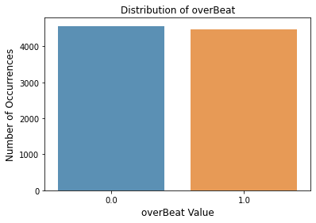

```python
overBeatCount = targetVars['overBeat'].value_counts()
sns.barplot(overBeatCount.index, overBeatCount.values, alpha=0.8)
plt.title('Distribution of overBeat')
plt.ylabel('Number of Occurrences', fontsize=12)
plt.xlabel('overBeat Value', fontsize=12)
plt.show()
```

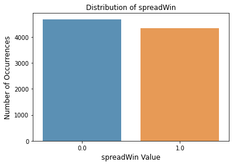

```python
spreadWinCount = targetVars['spreadWin'].value_counts()
sns.barplot(spreadWinCount.index, spreadWinCount.values, alpha=0.8)
plt.title('Distribution of spreadWin')
plt.ylabel('Number of Occurrences', fontsize=12)
plt.xlabel('spreadWin Value', fontsize=12)
plt.show()
```

## Summmary Statistics of the Numerical Predictors

Next, we will be analyzing the predictor variables.

Note: We are analyzing the values of these predictors before min max scaling.

```python
#Data frame showing the predictor variables
dataReducedpredNoTarget = dataReducedpred.drop(['spreadWin', 'overBeat'], axis=1)
```

```python
cols = [0,3]
dataReducedNum = dataReducedpredNoTarget.drop(dataReducedpredNoTarget.columns[cols],axis=1)
```

```python
dataReducedNum.describe()
```

|  | spread_favorite | over_under_line | weather_temperature | weather_wind_mph | homePointsFor | homePointsAgainst | awayPointsFor | awayPointsAgainst | DOME | DOME (Open Roof) | Fog | Rain | Rain \| Fog | Snow | Snow \| Fog | Snow \| Freezing Rain |
| --- | --- | --- | --- | --- | --- | --- | --- | --- | --- | --- | --- | --- | --- | --- | --- | --- |
| count | 9027.000000 | 9027.000000 | 9027.000000 | 9027.000000 | 9027.000000 | 9027.000000 | 9027.000000 | 9027.000000 | 9027.000000 | 9027.000000 | 9027.000000 | 9027.000000 | 9027.000000 | 9027.000000 | 9027.000000 | 9027.000000 |
| mean | 5.466711 | 41.981522 | 59.977955 | 7.208707 | 21.364057 | 21.208846 | 21.265338 | 21.232906 | 0.242716 | 0.005982 | 0.003102 | 0.011078 | 0.002105 | 0.001551 | 0.000554 | 0.000111 |
| std | 3.401257 | 4.721354 | 15.450566 | 5.746961 | 4.353043 | 3.722620 | 4.329450 | 3.727723 | 0.428749 | 0.077116 | 0.055610 | 0.104673 | 0.045832 | 0.039353 | 0.023530 | 0.010525 |
| min | 1.000000 | 28.000000 | -6.000000 | 0.000000 | 8.750000 | 10.312500 | 8.750000 | 10.312500 | 0.000000 | 0.000000 | 0.000000 | 0.000000 | 0.000000 | 0.000000 | 0.000000 | 0.000000 |
| 25% | 3.000000 | 38.500000 | 50.000000 | 0.000000 | 18.250000 | 18.750000 | 18.187500 | 18.777778 | 0.000000 | 0.000000 | 0.000000 | 0.000000 | 0.000000 | 0.000000 | 0.000000 | 0.000000 |
| 50% | 4.500000 | 42.000000 | 64.000000 | 7.000000 | 21.187500 | 21.000000 | 21.125000 | 21.000000 | 0.000000 | 0.000000 | 0.000000 | 0.000000 | 0.000000 | 0.000000 | 0.000000 | 0.000000 |
| 75% | 7.000000 | 45.000000 | 72.000000 | 11.000000 | 24.250000 | 23.812500 | 24.125000 | 23.812500 | 0.000000 | 0.000000 | 0.000000 | 0.000000 | 0.000000 | 0.000000 | 0.000000 | 0.000000 |
| max | 26.500000 | 63.000000 | 97.000000 | 40.000000 | 37.875000 | 33.312500 | 37.875000 | 33.312500 | 1.000000 | 1.000000 | 1.000000 | 1.000000 | 1.000000 | 1.000000 | 1.000000 | 1.000000 |

In order to better visualize these variables, we will look at their distrbutions on a histogram

```
array([[<matplotlib.axes._subplots.AxesSubplot object at 0x7f27f957eed0>,
      dtype=object)
```

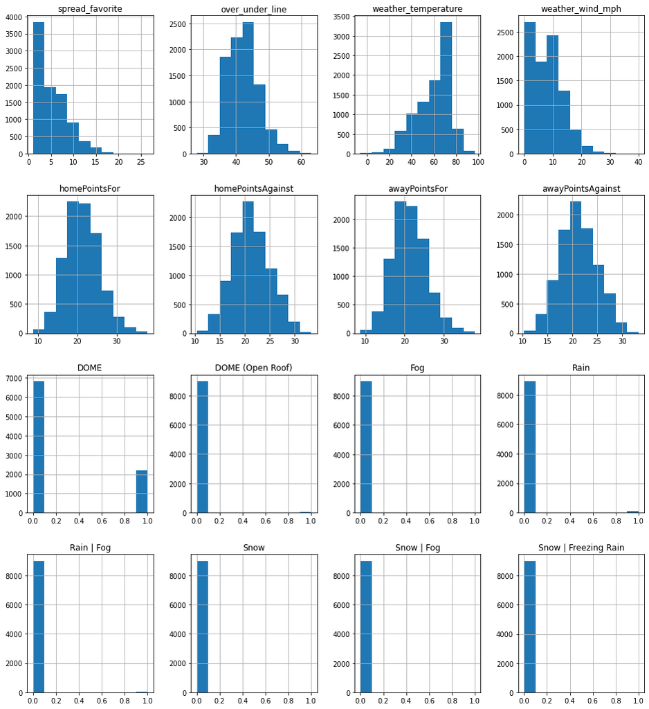

```python
dataReducedNum.hist(figsize = (16,18))
```

The variables of spreadFavorite and weatherWind have a strong right skew. The variables of weather temperature has a strong left skew. OverUnderLine variable is slightly skewed to the right. All Four the the 'points' variables seem to have somewhat of normal distribution.

The Dome and Weather variables are all binary. All of them do have class imbalence because there are significantly more 0s than 1s.

Finally, We will see how the numerical variables are correlated to the target variables. First we will see how the numerical variables are correlated to "OverBeat"

```python
#Creating a dataset that only includes overbeat and the numerical predictors
cols = [0,3,20]
dataReducedNum_overBeat = dataReducedpred.drop(dataReducedpred.columns[cols],axis=1)
```

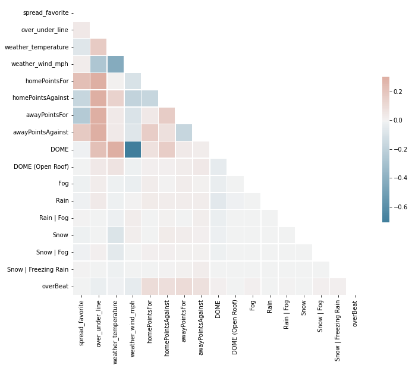

```python
# Compute the correlation matrix
corr = dataReducedNum_overBeat.corr()

# Generate a mask for the upper triangle
mask = np.triu(np.ones_like(corr, dtype=bool))

# Set up the matplotlib figure
f, ax = plt.subplots(figsize=(11, 9))

# Generate a custom diverging colormap
cmap = sns.diverging_palette(230, 20, as_cmap=True)

# Draw the heatmap with the mask and correct aspect ratio
sns.heatmap(corr, mask=mask, cmap=cmap, vmax=.3, center=0,
            square=True, linewidths=.5, cbar_kws={"shrink": .5})
```

If we look at how the variables are correlated to overBeat, we see that there isn't a strong correlation for any of the predictors and overBeat. There is a slight positive correlation with the 'Points' variables and overBeat. The othere correlations seems rather close to zero.

Next, We will look at the correlations and the predictor variables and spreadWin

```python
#Creating a dataset that only includes overbeat and the numerical predictors
cols = [0,3,19]
dataReducedNum_spreadWin = dataReducedpred.drop(dataReducedpred.columns[cols],axis=1)
```

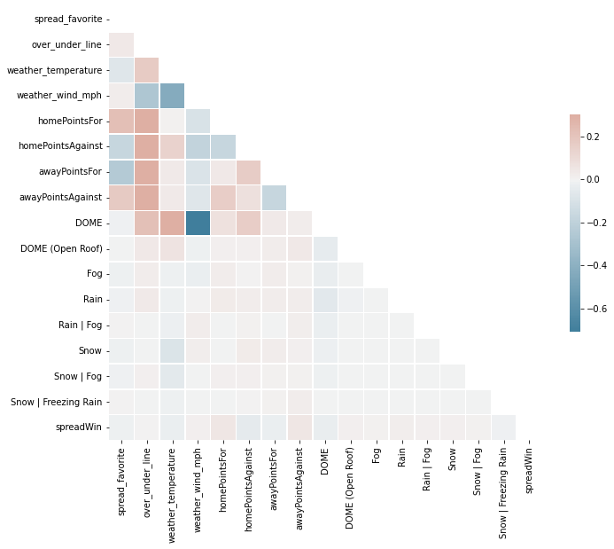

```python
# Compute the correlation matrix
corr = dataReducedNum_spreadWin.corr()

# Generate a mask for the upper triangle
mask = np.triu(np.ones_like(corr, dtype=bool))

# Set up the matplotlib figure
f, ax = plt.subplots(figsize=(11, 9))

# Generate a custom diverging colormap
cmap = sns.diverging_palette(230, 20, as_cmap=True)

# Draw the heatmap with the mask and correct aspect ratio
sns.heatmap(corr, mask=mask, cmap=cmap, vmax=.3, center=0,
            square=True, linewidths=.5, cbar_kws={"shrink": .5})
```

There are no strong correlations with spreadWin and any of the predictors. Many of the correlations seems close to 0 with either slight positive or slight negative correlations

## Summary Statistics of the Categorical Predictors

There are two categorical variables in the dataset, schedule_playoff and stadium_neutral. These are binary variables that have the values of true and false.

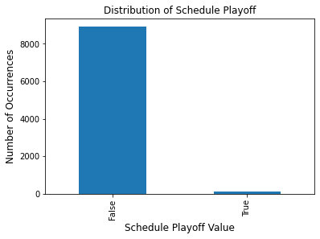

```python
dataReduced['schedule_playoff'].value_counts().plot(kind='bar')
plt.title('Distribution of Schedule Playoff')
plt.ylabel('Number of Occurrences', fontsize=12)
plt.xlabel('Schedule Playoff Value', fontsize=12)
```

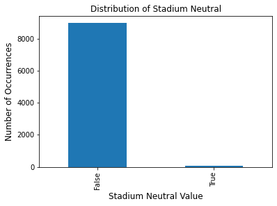

```python
dataReduced['stadium_neutral'].value_counts().plot(kind='bar')
plt.title('Distribution of Stadium Neutral')
plt.ylabel('Number of Occurrences', fontsize=12)
plt.xlabel('Stadium Neutral Value', fontsize=12)
```

Both of these variables have significantly more False values than True.

## Clustering

In this section we will continue exploration of the data via unsupervised clustering analysis. We will be using kMeans as our clustering method.

This section imports all the necessary Python packages (i.e. libraries) additionally required for executing the Python code in this section of the report for calculations and visualizations.

```python
from sklearn.cluster import KMeans
import pylab as pl
from sklearn.metrics import completeness_score, homogeneity_score
from sklearn.datasets import load_digits
from sklearn.decomposition import PCA
import matplotlib.pyplot as plt
```

Below is a kMeans implementation reused from our Machine Learning in Action (MLA) text book. Because the MLA version has the ability to use cosine and euclid distances and its random centroid starting point outputs different cluster results it provides more diversity in clusters we can compare and contrast results between itself and the sklearn's implementation.

```python
'''
k Means Clustering for Ch10 of Machine Learning in Action
@author: Peter Harrington
'''
from numpy import *

def distEuclid(vecA, vecB):
    return sqrt(sum(power(vecA - vecB, 2))) #la.norm(vecA-vecB)

# Helper function that calculates cosine distance
def distCosine(vecA, vecB):
    # Take 1 minus cosine similarity to convert cosine similarity to a cosine distance
    return (1 - (np.dot(vecA, vecB) / (np.linalg.norm(vecA) * np.linalg.norm(vecB))))

'''
randCent(), creates a set of k ran-dom  centroids  for  a  given  dataset.
The  random  centroids  need  to  be  within  thebounds of the dataset.
This is accomplished by finding the minimum and maximumvalues of each dimension
in the dataset.
Random values from 0 to 1.0 are then chosenand  scaled  by  the  range  and
minimum  value  to  ensure  that  the  random  points  arewithin  the  bounds
of  the  data.
'''
def randCent(dataSet, k):
	n = shape(dataSet)[1]
	centroids = zeros((k,n), dtype=float)
	for j in range(n): #create random cluster centers
		minJ = min(dataSet[:,j])
		rangeJ = float(max(dataSet[:,j]) - minJ)
		centroids[:,j] = minJ + rangeJ * random.rand(k)
	return centroids

# kMeans function
def kMeans(dataSet, k, distMeas=distCosine, createCent=randCent):
    m = shape(dataSet)[0]
    clusterAssment = zeros((m,2)) #create mat to assign data points
                                  #to a centroid, also holds SE of each point
    centroids = createCent(dataSet, k)
    clusterChanged = True
    while clusterChanged:
        clusterChanged = False
        for i in range(m): #for each data point assign it to the closest centroid
            minDist = inf; minIndex = -1
            for j in range(k):
                distJI = distMeas(centroids[j,:],dataSet[i,:])
                if distJI < minDist:
                    minDist = distJI; minIndex = j
            if clusterAssment[i,0] != minIndex: clusterChanged = True
            clusterAssment[i,:] = minIndex,minDist**2
        # print centroids
        for cent in range(k):#recalculate centroids
            ptsInClust = dataSet[nonzero(clusterAssment[:,0]==cent)[0]] #get all the point in this cluster - Note: this was incorrect in the original distribution.
            if(len(ptsInClust)!=0):
                centroids[cent,:] = mean(ptsInClust, axis=0) #assign centroid to mean - Note condition was added 10/28/2013
    return centroids, clusterAssment
```

In this section we define a helper function to perform kMeans evaluation for varying kMeans model parameters. The function below will take in the

- data set of NFL objects
- target set of NFL labels for both spread winners and over/under winners
- range of k values to evaluate against
- number of clustering runs/executions to perform for each k
- kmeans implementation type to use (default is sklearn)

The function will execute clustering for each k value in range multiplied by the number of runs. After complete a report will be generated for each k value displaying a 2D scatter plot visualization of each cluster plot for k using PCA to reduce dimensionality to 2 dimensions. Additionally a summary table will be generated for the completeness and homogeneity scores for both the spreadWin and overBeat labels.

```python
def kmeans_clustering(data, target, k_range, runs, kmeans_type='sklearn'):
  # Convert data into numpy array
  dataArr = np.array(data)

  for k in k_range:
    print("===============================================================================")
    print("Running kmeans for k =", k)
    print("===============================================================================")

    # Initialize lists to store kMeans metrics
    spreadWin_completeness = []
    spreadWin_homogeneity = []
    overBeat_completeness = []
    overBeat_homogeneity = []

    fig = plt.figure(figsize=(20,20))
    subplot_loc = 331

    for i in range(runs):
      # Use scikit learn's kmeans implementation to split the data into k clusters
      if (kmeans_type == 'sklearn'):
        kmeans = KMeans(n_clusters=k, random_state=123)
        kmeans.fit(dataArr)
        clusters = kmeans.predict(dataArr)
      elif (kmeans_type == 'mla_euclid'):
        centroids, clusters = kMeans(dataArr, k, distEuclid)
        clusters = clusters[:,0]
      elif (kmeans_type == 'mla_cosine'):
        centroids, clusters = kMeans(dataArr, k, distCosine)
        clusters = clusters[:,0]

      # Gather both cluster and target data for spreadWin label
      c = np.array(clusters.astype(int))
      t = np.array(target['spreadWin'].astype(int)).flatten()

      # Calculate spreadWin completeness and homogeneity scores and store
      spreadWin_completeness.append(completeness_score(t, c))
      spreadWin_homogeneity.append(homogeneity_score(t, c))

      # Gather both cluster and target data for overBeat label
      c = np.array(clusters.astype(int))
      t = np.array(target['overBeat'].astype(int)).flatten()

      # Calculate overBeat completeness and homogeneity scores and store
      overBeat_completeness.append(completeness_score(t, c))
      overBeat_homogeneity.append(homogeneity_score(t, c))

      # Convert data into 2D using PCA for cluster visualization
      pca = PCA(2)
      df = pca.fit_transform(data)

      # Plot the clusters along axis' of length 3
      ax = fig.add_subplot(subplot_loc)
      subplot_loc += 1
      u_labels = np.unique(clusters)
      for i in u_labels:
          plt.scatter(df[clusters == i , 0] , df[clusters == i , 1] , label = i)
      plt.legend()
      plt.plot()

    # Display the results for this k value starting with showing the 2D visualized cluster plots
    plt.show()

    # Gather and print stat table for spreadWin cluster scores
    print("spreadWin Cluster Score Summary:")
    print("\tMean completeness score = " + "%.4f" % np.mean(spreadWin_completeness))
    best_run = np.where(spreadWin_completeness == np.amax(spreadWin_completeness))[0][0]
    print("\tBest completeness score = " + "%.4f" % np.amax(spreadWin_completeness) + ", for run = " + str(best_run))
    print("\tMean homogeneity score = " + "%.4f" % np.mean(spreadWin_homogeneity))
    best_run = np.where(spreadWin_homogeneity == np.amax(spreadWin_homogeneity))[0][0]
    print("\tBest homogeneity score = " + "%.4f" % np.amax(spreadWin_homogeneity) + ", for run = " + str(best_run))

    # Gather and print stat table for overBeat cluster scores
    print("overBeat Cluster Score Summary:")
    print("\tMean completeness score = " + "%.4f" % np.mean(overBeat_completeness))
    best_run = np.where(overBeat_completeness == np.amax(overBeat_completeness))[0][0]
    print("\tBest completeness score = " + "%.4f" % np.amax(overBeat_completeness) + ", for run = " + str(best_run))
    print("\tMean homogeneity score = " + "%.4f" % np.mean(overBeat_homogeneity))
    best_run = np.where(overBeat_homogeneity == np.amax(overBeat_homogeneity))[0][0]
    print("\tBest homogeneity score = " + "%.4f" % np.amax(overBeat_homogeneity) + ", for run = " + str(best_run))
```

First we will perform and kMeans evaluation for k from 2 to 8 using sklearn's kMeans implementation. Because sklearn's kMeans implementation appears to generate the same clusters for each run of k we will only run once for each k.

As can be seen by the completeness and homogeneity scores of each run, all scores are near zero and thus none are very good clusters. This is also supported by the 2D plots as all the points seem to be in 1 cluster with only a few outliers. Because of these poor results further silhouette analysis was not peformed on each kMeans execution as there doesn't appear to be interesting information to be retrieved from these clusters.

```
===============================================================================
Running kmeans for k = 2
===============================================================================
```

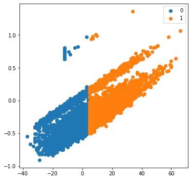

```
spreadWin Cluster Score Summary:
	Mean completeness score = 0.0003
	Best completeness score = 0.0003, for run = 0
	Mean homogeneity score = 0.0002
	Best homogeneity score = 0.0002, for run = 0
overBeat Cluster Score Summary:
	Mean completeness score = 0.0000
	Best completeness score = 0.0000, for run = 0
	Mean homogeneity score = 0.0000
	Best homogeneity score = 0.0000, for run = 0
===============================================================================
Running kmeans for k = 3
===============================================================================
```

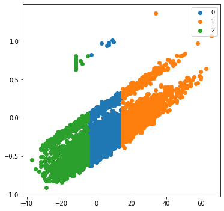

```
spreadWin Cluster Score Summary:
	Mean completeness score = 0.0004
	Best completeness score = 0.0004, for run = 0
	Mean homogeneity score = 0.0007
	Best homogeneity score = 0.0007, for run = 0
overBeat Cluster Score Summary:
	Mean completeness score = 0.0002
	Best completeness score = 0.0002, for run = 0
	Mean homogeneity score = 0.0003
	Best homogeneity score = 0.0003, for run = 0
===============================================================================
Running kmeans for k = 4
===============================================================================
```

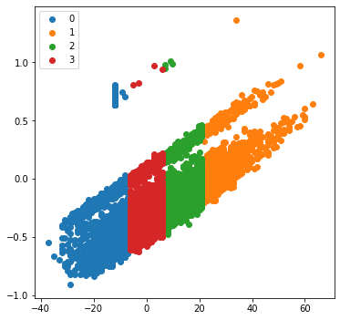

```
spreadWin Cluster Score Summary:
	Mean completeness score = 0.0004
	Best completeness score = 0.0004, for run = 0
	Mean homogeneity score = 0.0006
	Best homogeneity score = 0.0006, for run = 0
overBeat Cluster Score Summary:
	Mean completeness score = 0.0001
	Best completeness score = 0.0001, for run = 0
	Mean homogeneity score = 0.0002
	Best homogeneity score = 0.0002, for run = 0
===============================================================================
Running kmeans for k = 5
===============================================================================
```

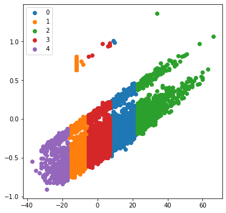

```
spreadWin Cluster Score Summary:
	Mean completeness score = 0.0003
	Best completeness score = 0.0003, for run = 0
	Mean homogeneity score = 0.0006
	Best homogeneity score = 0.0006, for run = 0
overBeat Cluster Score Summary:
	Mean completeness score = 0.0006
	Best completeness score = 0.0006, for run = 0
	Mean homogeneity score = 0.0013
	Best homogeneity score = 0.0013, for run = 0
===============================================================================
Running kmeans for k = 6
===============================================================================
```

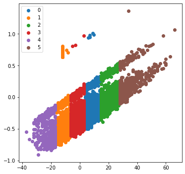

```
spreadWin Cluster Score Summary:
	Mean completeness score = 0.0003
	Best completeness score = 0.0003, for run = 0
	Mean homogeneity score = 0.0007
	Best homogeneity score = 0.0007, for run = 0
overBeat Cluster Score Summary:
	Mean completeness score = 0.0006
	Best completeness score = 0.0006, for run = 0
	Mean homogeneity score = 0.0014
	Best homogeneity score = 0.0014, for run = 0
===============================================================================
Running kmeans for k = 7
===============================================================================
```

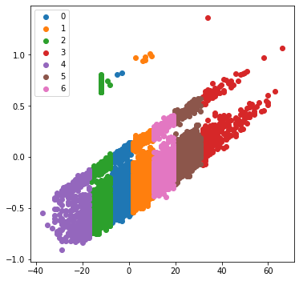

```
spreadWin Cluster Score Summary:
	Mean completeness score = 0.0003
	Best completeness score = 0.0003, for run = 0
	Mean homogeneity score = 0.0007
	Best homogeneity score = 0.0007, for run = 0
overBeat Cluster Score Summary:
	Mean completeness score = 0.0005
	Best completeness score = 0.0005, for run = 0
	Mean homogeneity score = 0.0013
	Best homogeneity score = 0.0013, for run = 0
===============================================================================
Running kmeans for k = 8
===============================================================================
```

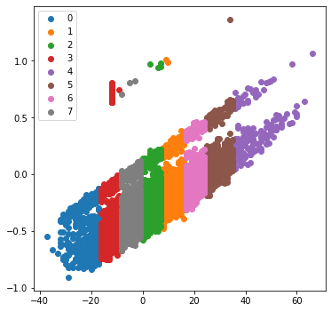

```
spreadWin Cluster Score Summary:
	Mean completeness score = 0.0004
	Best completeness score = 0.0004, for run = 0
	Mean homogeneity score = 0.0010
	Best homogeneity score = 0.0010, for run = 0
overBeat Cluster Score Summary:
	Mean completeness score = 0.0005
	Best completeness score = 0.0005, for run = 0
	Mean homogeneity score = 0.0014
	Best homogeneity score = 0.0014, for run = 0
```

```python
# Set a random seed value for consistency in kmeans runs
random.seed(1223334444)

kmeans_clustering(dataReduced, targetVars, range(2, 9), 1, kmeans_type='sklearn')
```

Second we will perform and kMeans evaluation for k from 2 to 8 using MLA's Euclid distance implementation. We will run 3 kMeans generations for each k.

As can be seen by the completeness and homogeneity scores of each run, all scores are near zero and thus none are very good clusters. This is also supported by the 2D plots as all the points seem to be in 1 cluster with only a few outliers. Because of these poor results further silhouette analysis was not peformed on each kMeans execution as there doesn't appear to be interesting information to be retrieved from these clusters.

```
===============================================================================
Running kmeans for k = 2
===============================================================================
```

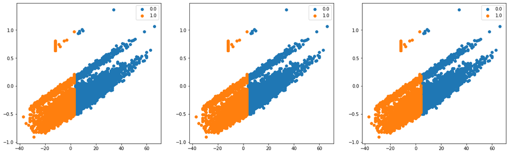

```
spreadWin Cluster Score Summary:
	Mean completeness score = 0.0002
	Best completeness score = 0.0003, for run = 2
	Mean homogeneity score = 0.0002
	Best homogeneity score = 0.0002, for run = 2
overBeat Cluster Score Summary:
	Mean completeness score = 0.0000
	Best completeness score = 0.0000, for run = 0
	Mean homogeneity score = 0.0000
	Best homogeneity score = 0.0000, for run = 0
===============================================================================
Running kmeans for k = 3
===============================================================================
```

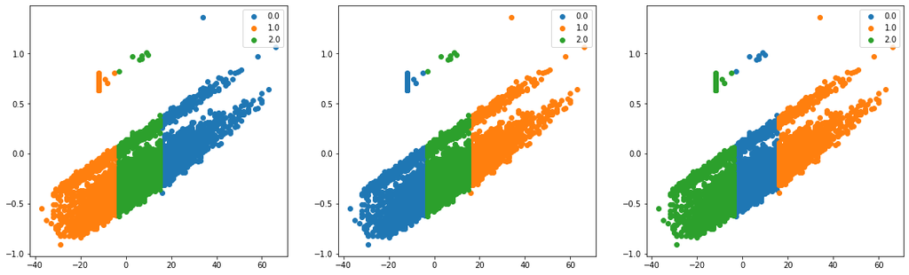

```
spreadWin Cluster Score Summary:
	Mean completeness score = 0.0003
	Best completeness score = 0.0003, for run = 2
	Mean homogeneity score = 0.0005
	Best homogeneity score = 0.0005, for run = 0
overBeat Cluster Score Summary:
	Mean completeness score = 0.0001
	Best completeness score = 0.0001, for run = 2
	Mean homogeneity score = 0.0002
	Best homogeneity score = 0.0002, for run = 0
===============================================================================
Running kmeans for k = 4
===============================================================================
```

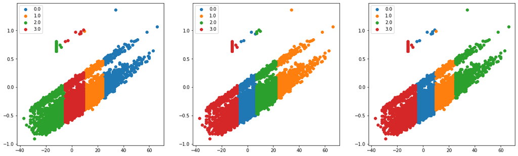

```
spreadWin Cluster Score Summary:
	Mean completeness score = 0.0004
	Best completeness score = 0.0004, for run = 0
	Mean homogeneity score = 0.0006
	Best homogeneity score = 0.0006, for run = 0
overBeat Cluster Score Summary:
	Mean completeness score = 0.0001
	Best completeness score = 0.0001, for run = 0
	Mean homogeneity score = 0.0002
	Best homogeneity score = 0.0003, for run = 0
===============================================================================
Running kmeans for k = 5
===============================================================================
```

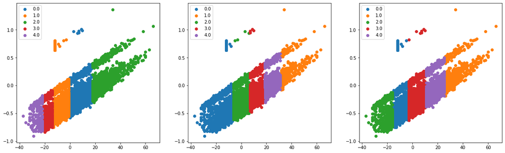

```
spreadWin Cluster Score Summary:
	Mean completeness score = 0.0003
	Best completeness score = 0.0004, for run = 1
	Mean homogeneity score = 0.0006
	Best homogeneity score = 0.0007, for run = 1
overBeat Cluster Score Summary:
	Mean completeness score = 0.0003
	Best completeness score = 0.0005, for run = 2
	Mean homogeneity score = 0.0007
	Best homogeneity score = 0.0010, for run = 2
===============================================================================
Running kmeans for k = 6
===============================================================================
```

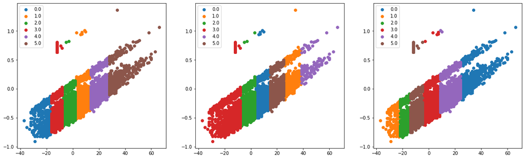

```
spreadWin Cluster Score Summary:
	Mean completeness score = 0.0004
	Best completeness score = 0.0005, for run = 2
	Mean homogeneity score = 0.0009
	Best homogeneity score = 0.0012, for run = 2
overBeat Cluster Score Summary:
	Mean completeness score = 0.0005
	Best completeness score = 0.0005, for run = 0
	Mean homogeneity score = 0.0010
	Best homogeneity score = 0.0013, for run = 0
===============================================================================
Running kmeans for k = 7
===============================================================================
```

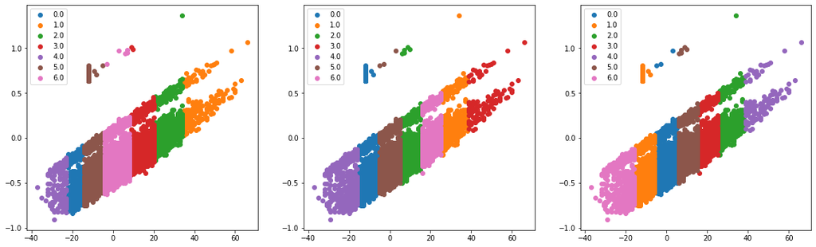

```
spreadWin Cluster Score Summary:
	Mean completeness score = 0.0004
	Best completeness score = 0.0005, for run = 0
	Mean homogeneity score = 0.0008
	Best homogeneity score = 0.0012, for run = 0
overBeat Cluster Score Summary:
	Mean completeness score = 0.0007
	Best completeness score = 0.0008, for run = 1
	Mean homogeneity score = 0.0017
	Best homogeneity score = 0.0019, for run = 1
===============================================================================
Running kmeans for k = 8
===============================================================================
```

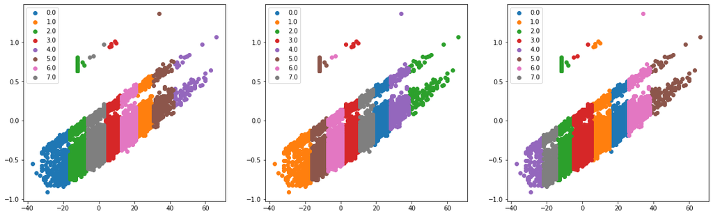

```
spreadWin Cluster Score Summary:
	Mean completeness score = 0.0004
	Best completeness score = 0.0004, for run = 2
	Mean homogeneity score = 0.0009
	Best homogeneity score = 0.0011, for run = 2
overBeat Cluster Score Summary:
	Mean completeness score = 0.0006
	Best completeness score = 0.0007, for run = 1
	Mean homogeneity score = 0.0016
	Best homogeneity score = 0.0017, for run = 1
```

```python
kmeans_clustering(dataReduced, targetVars, range(2, 9), 3, kmeans_type='mla_euclid')
```

Last we will perform and kMeans evaluation for k from 2 to 8 using MLA's Cosine distance implementation. We will run 3 kMeans generations for each k.

Though it was interesting to see the different clustering pattern as compared to the more "vertical striped" clustering seen in the last 2 results, unfortunately the completeness and homogeneity scores of each run are still poor. All scores are near zero and thus none are very good clusters. This is also supported by the 2D plots as all the points seem to be in 1 cluster with only a few outliers. Because of these poor results further silhouette analysis was not peformed on each kMeans execution as there doesn't appear to be interesting information to be retrieved from these clusters.

```
===============================================================================
Running kmeans for k = 2
===============================================================================
```

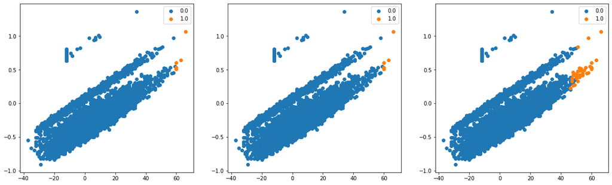

```
spreadWin Cluster Score Summary:
	Mean completeness score = 0.0141
	Best completeness score = 0.0201, for run = 0
	Mean homogeneity score = 0.0001
	Best homogeneity score = 0.0001, for run = 0
overBeat Cluster Score Summary:
	Mean completeness score = 0.0018
	Best completeness score = 0.0021, for run = 0
	Mean homogeneity score = 0.0000
	Best homogeneity score = 0.0000, for run = 2
===============================================================================
Running kmeans for k = 3
===============================================================================
```

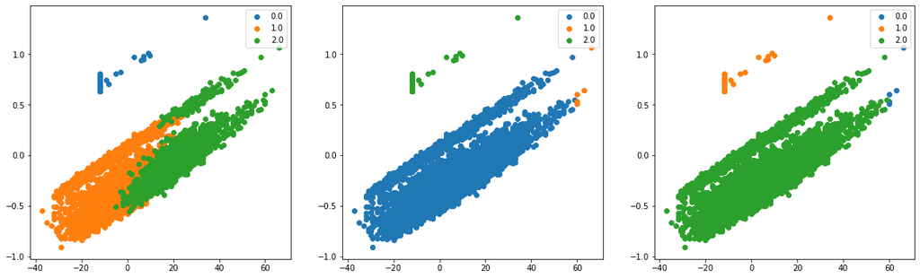

```
spreadWin Cluster Score Summary:
	Mean completeness score = 0.0008
	Best completeness score = 0.0009, for run = 2
	Mean homogeneity score = 0.0007
	Best homogeneity score = 0.0007, for run = 0
overBeat Cluster Score Summary:
	Mean completeness score = 0.0005
	Best completeness score = 0.0009, for run = 0
	Mean homogeneity score = 0.0006
	Best homogeneity score = 0.0013, for run = 0
===============================================================================
Running kmeans for k = 4
===============================================================================
```

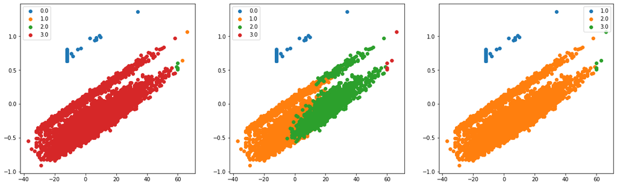

```
spreadWin Cluster Score Summary:
	Mean completeness score = 0.0008
	Best completeness score = 0.0009, for run = 2
	Mean homogeneity score = 0.0007
	Best homogeneity score = 0.0008, for run = 1
overBeat Cluster Score Summary:
	Mean completeness score = 0.0006
	Best completeness score = 0.0009, for run = 1
	Mean homogeneity score = 0.0007
	Best homogeneity score = 0.0013, for run = 1
===============================================================================
Running kmeans for k = 5
===============================================================================
```

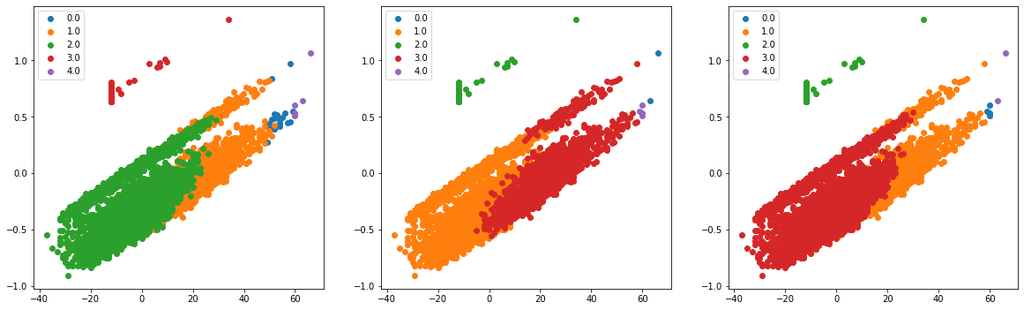

```
spreadWin Cluster Score Summary:
	Mean completeness score = 0.0006
	Best completeness score = 0.0006, for run = 0
	Mean homogeneity score = 0.0008
	Best homogeneity score = 0.0009, for run = 0
overBeat Cluster Score Summary:
	Mean completeness score = 0.0009
	Best completeness score = 0.0011, for run = 2
	Mean homogeneity score = 0.0014
	Best homogeneity score = 0.0016, for run = 2
===============================================================================
Running kmeans for k = 6
===============================================================================
```

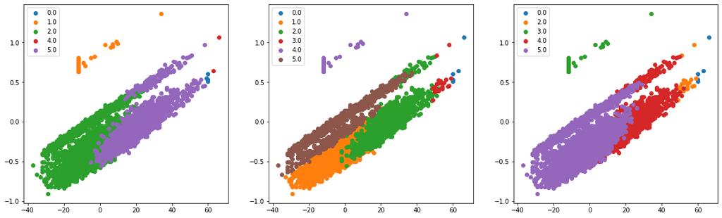

```
spreadWin Cluster Score Summary:
	Mean completeness score = 0.0005
	Best completeness score = 0.0006, for run = 2
	Mean homogeneity score = 0.0009
	Best homogeneity score = 0.0009, for run = 2
overBeat Cluster Score Summary:
	Mean completeness score = 0.0008
	Best completeness score = 0.0011, for run = 0
	Mean homogeneity score = 0.0013
	Best homogeneity score = 0.0016, for run = 0
===============================================================================
Running kmeans for k = 7
===============================================================================
```

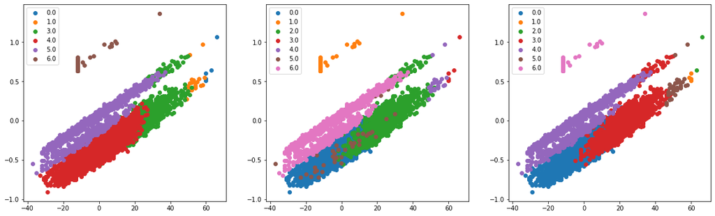

```
spreadWin Cluster Score Summary:
	Mean completeness score = 0.0005
	Best completeness score = 0.0005, for run = 1
	Mean homogeneity score = 0.0009
	Best homogeneity score = 0.0011, for run = 1
overBeat Cluster Score Summary:
	Mean completeness score = 0.0007
	Best completeness score = 0.0008, for run = 2
	Mean homogeneity score = 0.0013
	Best homogeneity score = 0.0014, for run = 2
===============================================================================
Running kmeans for k = 8
===============================================================================
```

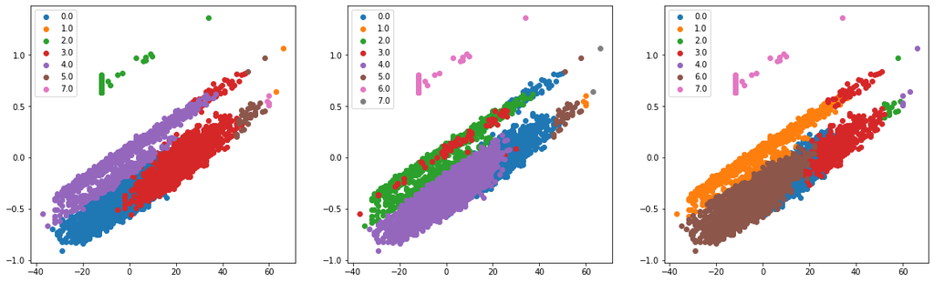

```
spreadWin Cluster Score Summary:
	Mean completeness score = 0.0005
	Best completeness score = 0.0005, for run = 1
	Mean homogeneity score = 0.0010
	Best homogeneity score = 0.0011, for run = 2
overBeat Cluster Score Summary:
	Mean completeness score = 0.0007
	Best completeness score = 0.0008, for run = 0
	Mean homogeneity score = 0.0014
	Best homogeneity score = 0.0014, for run = 1
```

```python
kmeans_clustering(dataReduced, targetVars, range(2, 9), 3, kmeans_type='mla_cosine')
```

### Clustering Summary

Unfortunately due to poor scores for each of the kMeans runs above the exploration here did not generate any information that can be used to enhance predictions for our betting strategies. It does seem to confirm that all the data is fairly well clustered in one monolithic cluster making it difficult to sort through the noise for the two labels of interest we have.

# Supervised Learning

## k-Nearest Neighbors

In this section we will build multiple kNN supervised learning models varying and tuning parameters to try to optimize predictive qualities.

This section imports all the necessary Python packages (i.e. libraries) additionally required for executing the Python code in this section of the report for calculations and visualizations.

```python
from sklearn.neighbors import KNeighborsClassifier
from sklearn.model_selection import train_test_split
from sklearn import metrics
from sklearn.metrics import classification_report, confusion_matrix
from sklearn.metrics import roc_curve, auc
from sklearn.metrics import roc_auc_score, plot_roc_curve
import matplotlib.pyplot as plt
```

In this section we define a helper function to perform kNN evaluation for varying kNN model parameters. The function below will take in the

- data set of NFL objects
- target set of NFL labels for both spread winners and over/under winners
- range of k values to evaluate against
- a similarity function to use for kNN (default is Euclidean similarity)
- p dimension for when Minkowski similarity is chosen (default is 2; i.e. Euclidean)

The function will divide the data into an 80/20 split for training and test respectively. Then it will generate the kNN model for each k value using the training data, predict with the test data, and calculate the overall accuracy along with precision for the label classes. It will do this for both the spread winner label and the over/under winner label. Note that precision for both classes was selected as another metric to analyze as it can be very useful in sports gambling (ex. if a model is very much better at selecting overs than unders we'd want to know when using for betting strategies) Also worth noting here is that the kNN model generation will use distance-based weighting to help break ties as it is expected many k values will be even and with a 2 class label create many opportunity for ties.

At the end the function will generate a summary report of the mean, median, and best accuracy and precisions along with a plot for each for visualization.

```python
def knn_evaluation(data, target, k_range, similarity_metric='euclidean', p_dim=2):

  # Create train/test split of the data and targets with a 80/20 split.  Also pass in a random state for result repeatability
  data_train, data_test, target_train, target_test = train_test_split(data, target, test_size=0.2, random_state=123)

  # Initialize lists to store kNN results
  spreadWin_scores = []
  spreadWin_class_reports = []
  overBeat_scores = []
  overBeat_class_reports = []

  # Loop through for each k passed into this function
  for k in k_range:
    # Use sklearn's kNN classifier for current k and similarity metric passed in to create a classifier for the spreadWin target.  We also
    # use weights value of distance to break ties as some k values used are expected to be even.
    knn_sw = KNeighborsClassifier(n_neighbors=k, weights='distance', metric=similarity_metric, p=p_dim)
    knn_sw.fit(data_train, target_train['spreadWin'])

    # Predict labels using test data
    knn_pred_sw = knn_sw.predict(data_test)

    # Evaluate accurray and classification reports for the spreadWin label and store them
    spreadWin_scores.append(metrics.accuracy_score(target_test['spreadWin'], knn_pred_sw))
    spreadWin_class_reports.append(classification_report(target_test['spreadWin'], knn_pred_sw, output_dict=True))

    # Use sklearn's kNN classifier for current k and similarity metric passed in to create a classifier for the overBeat target.  We also
    # use weights value of distance to break ties as some k values used are expected to be even.
    knn_ob = KNeighborsClassifier(n_neighbors=k, weights='distance', metric=similarity_metric, p=p_dim)
    knn_ob.fit(data_train, target_train['overBeat'])

    # Predict labels using test data
    knn_pred_ob = knn_ob.predict(data_test)

    # Evaluate accurray and classification reports for the overBeat label and store them
    overBeat_scores.append(metrics.accuracy_score(target_test['overBeat'], knn_pred_ob))
    overBeat_class_reports.append(classification_report(target_test['overBeat'], knn_pred_ob, output_dict=True))

  # Use accuracy scores attained and plot them for spreadWin and overBeat labels
  plt.plot(k_range, spreadWin_scores, label="spreadWin")
  plt.plot(k_range, overBeat_scores, label="overBeat")
  plt.legend()
  plt.title("kNN Accuracy for " + similarity_metric)
  plt.xlabel("k")
  plt.ylabel("Test Accuracy")
  plt.show()

  # Gather and print stat table for spreadWin accuracy
  print("spreadWin Accuracy Summary:")
  print("\tMean accuracy = " + "%.4f" % np.mean(spreadWin_scores))
  print("\tMedian accuracy = " + "%.4f" % np.median(spreadWin_scores))
  best_k = np.where(spreadWin_scores == np.amax(spreadWin_scores))[0][0] + min(k_range)
  print("\tBest accuracy = " + "%.4f" % np.amax(spreadWin_scores) + ", for k = " + str(best_k))

  # Gather and print stat table for overBeat accuracy
  print("overBeat Accuracy Summary:")
  print("\tMean accuracy = " + "%.4f" % np.mean(overBeat_scores))
  print("\tMedian accuracy = " + "%.4f" % np.median(overBeat_scores))
  best_k = np.where(overBeat_scores == np.amax(overBeat_scores))[0][0] + min(k_range)
  print("\tBest accuracy = " + "%.4f" % np.amax(overBeat_scores) + ", for k = " + str(best_k) + "\n\n")

  # Filter for the precision for both classes of spreadWin label
  spreadWin_precision_0 = []
  spreadWin_precision_1 = []
  for i, cr in enumerate(spreadWin_class_reports):
    spreadWin_precision_0.append(cr['0.0']['precision'])
    spreadWin_precision_1.append(cr['1.0']['precision'])

  # Plot the precision for each class in the spreadWin label
  plt.plot(k_range, spreadWin_precision_0, label="spreadWin underdog")
  plt.plot(k_range, spreadWin_precision_1, label="spreadWin favorite")
  plt.legend()
  plt.title("kNN SpreadWin Precision for " + similarity_metric)
  plt.xlabel("k")
  plt.ylabel("Precision")
  plt.show()

  # Gather and print stat table for spreadWin=0 (underdog) precision
  print("Underdog (spreadWin=0) Precision Summary:")
  print("\tMean precision = " + "%.4f" % np.mean(spreadWin_precision_0))
  print("\tMedian precision = " + "%.4f" % np.median(spreadWin_precision_0))
  best_k = np.where(spreadWin_precision_0 == np.amax(spreadWin_precision_0))[0][0] + min(k_range)
  print("\tBest precision = " + "%.4f" % np.amax(spreadWin_precision_0) + ", for k = " + str(best_k))

  # Gather and print stat table for spreadWin=1 (favorite) precision
  print("Favorite (spreadWin=1) Precision Summary:")
  print("\tMean precision = " + "%.4f" % np.mean(spreadWin_precision_1))
  print("\tMedian precision = " + "%.4f" % np.median(spreadWin_precision_1))
  best_k = np.where(spreadWin_precision_1 == np.amax(spreadWin_precision_1))[0][0] + min(k_range)
  print("\tBest precision = " + "%.4f" % np.amax(spreadWin_precision_1) + ", for k = " + str(best_k) + "\n\n")

  # Filter for the precision for both classes of overBeat label
  overBeat_precision_0 = []
  overBeat_precision_1 = []
  for i, cr in enumerate(overBeat_class_reports):
    overBeat_precision_0.append(cr['0.0']['precision'])
    overBeat_precision_1.append(cr['1.0']['precision'])

  # Plot the precision for each class in the overBeat label
  plt.plot(k_range, overBeat_precision_0, label="overBeat under")
  plt.plot(k_range, overBeat_precision_1, label="overBeat over")
  plt.legend()
  plt.title("kNN overBeat Precision for " + similarity_metric)
  plt.xlabel("k")
  plt.ylabel("Precision")
  plt.show()

  # Gather and print stat table for spreadWin=0 (underdog) precision
  print("Under (overBeat=0) Precision Summary:")
  print("\tMean precision = " + "%.4f" % np.mean(overBeat_precision_0))
  print("\tMedian precision = " + "%.4f" % np.median(overBeat_precision_0))
  best_k = np.where(overBeat_precision_0 == np.amax(overBeat_precision_0))[0][0] + min(k_range)
  print("\tBest precision = " + "%.4f" % np.amax(overBeat_precision_0) + ", for k = " + str(best_k))

  # Gather and print stat table for spreadWin=1 (favorite) precision
  print("Over (overBeat=1) Precision Summary:")
  print("\tMean precision = " + "%.4f" % np.mean(overBeat_precision_1))
  print("\tMedian precision = " + "%.4f" % np.median(overBeat_precision_1))
  best_k = np.where(overBeat_precision_1 == np.amax(overBeat_precision_1))[0][0] + min(k_range)
  print("\tBest precision = " + "%.4f" % np.amax(overBeat_precision_1) + ", for k = " + str(best_k) + "\n\n")
```